Python Code for Portfolio Optimization  
Chapter 12 – Graph-Based Portfolios

Daniel P. Palomar (2025). [Portfolio Optimization: Theory and Application.](https://portfoliooptimizationbook.com/) Cambridge University Press.

Last update: November 1, 2026

Contributors:

- [Daniel Palomar](https://www.danielppalomar.com/)
- DeepSeek V4.1 Flash (DeepSeek, via [OpenCode](https://opencode.ai))

# Libraries

The following libraries are used in the examples:

```python
# Core numerical computing
import numpy as np
import pandas as pd
import warnings
warnings.filterwarnings('ignore')

# Clustering and distances
from scipy.cluster.hierarchy import dendrogram
from scipy.spatial.distance import pdist, squareform

# Optimization (for the GMVP and MVP benchmarks)
import cvxpy as cp

# Financial data and performance metrics
import empyrical as emp

# Book data (pip install "git+https://github.com/dppalomar/pob.git#subdirectory=python")
from pob_python import SP500_stocks_2015to2020

# Dependence measures used as "sophisticated" graphs
from skfolio.distance import DistanceCorrelation

# Plotting
import matplotlib.pyplot as plt
import seaborn as sns
sns.set_theme(style="darkgrid")

# Progress bars
from tqdm.auto import tqdm

# color palette (the same used in the R companion)
BLUE, RED, BLACK = "#2980b9", "#c0392b", "black"
```

$\def\bm#1{\boldsymbol{#1}}$ $\def\textm#1{\textsf{#1}}$ $\def\T{{\mkern-2mu\raise-1mu\mathsf{T}}}$ $\def\R{\mathbb{R}}$ $\def\E{\rm I\kern-.2em E}$ $\def\w{\bm{w}}$ $\def\bmu{\bm{\mu}}$ $\def\bSigma{\bm{\Sigma}}$

# Helper functions

The R companion relies on four external pieces of software: `hclust()` for the hierarchical clustering, `portfolioBacktest` for the walk-forward backtests, `fingraph` for the heavy-tail graph learning, and `CVXR` for the GMVP and MVP benchmarks. Python has the last two in other forms (`cvxpy` and the `skfolio.distance` estimators), while the clustering and the backtest engine are written here explicitly, which makes the algorithms behind this chapter visible.

The notebook is organized around the same convention as the other chapters: a portfolio design function takes a `lookback` window of prices and returns a vector of weights, so that the same function can be used in a single backtest and in the multiple randomized backtests.

## Hierarchical clustering

The function returns the linkage matrix in the format used by SciPy (children, height, size), from which the dendrogram, the leaf order, and the clusters obtained by cutting the tree are obtained:

```python
def hclust(D, method="single"):
    """
    Agglomerative hierarchical clustering via the Lance-Williams recursion.

    Parameters
    ----------
    D : np.ndarray
        N x N symmetric matrix of distances (the diagonal is ignored).
    method : {"single", "complete", "average", "ward"}, default "single"
        Linkage method. "ward" applies Ward's update to the distances themselves,
        as R's hclust(method = "ward.D").

    Returns
    -------
    np.ndarray
        (N - 1) x 4 linkage matrix: children of each merge, merge height and
        number of leaves of the new cluster.
    """
    D = np.asarray(D, dtype=float)
    N = len(D)
    if N == 1:
        return np.zeros((0, 4))

    # ids N, N+1, ... denote the internal nodes of the tree
    d = np.full((2 * N - 1, 2 * N - 1), np.inf)
    d[:N, :N] = D
    np.fill_diagonal(d, np.inf)

    size = np.ones(2 * N - 1)
    active = np.zeros(2 * N - 1, dtype=bool)
    active[:N] = True
    Z = np.zeros((N - 1, 4))
    next_id = N

    for step in range(N - 1):
        # closest pair among the active clusters
        sub = np.where(active[:, None] & active[None, :], d, np.inf)
        i, j = divmod(int(np.argmin(sub)), len(d))
        if i > j:
            i, j = j, i
        Z[step] = [i, j, d[i, j], size[i] + size[j]]

        # Lance-Williams update of the distances to the new cluster
        ni, nj = size[i], size[j]
        if method == "single":
            new_d = np.minimum(d[i], d[j])
        elif method == "complete":
            new_d = np.maximum(d[i], d[j])
        elif method == "average":
            new_d = (ni * d[i] + nj * d[j]) / (ni + nj)
        elif method in ("ward", "ward.D"):
            nk = size
            new_d = ((ni + nk) * d[i] + (nj + nk) * d[j] - nk * d[i, j]) / (ni + nj + nk)
        else:
            raise ValueError(f"unknown linkage method: {method}")

        new_d[i] = np.inf
        new_d[j] = np.inf
        new_d[~active] = np.inf

        d[next_id] = new_d
        d[:, next_id] = new_d
        d[i, :] = d[j, :] = np.inf
        d[:, i] = d[:, j] = np.inf
        size[next_id] = ni + nj
        active[i] = active[j] = False
        active[next_id] = True
        next_id += 1

    return Z


def leaves_order(Z, N):
    """
    Leaf order of a dendrogram (R's hc$order).

    Parameters
    ----------
    Z : np.ndarray
        Linkage matrix.
    N : int
        Number of leaves.

    Returns
    -------
    list of int
        Order in which the leaves appear from left to right.
    """
    children = {k + N: (int(row[0]), int(row[1])) for k, row in enumerate(Z)}
    order = []

    def walk(node):
        if node < N:
            order.append(node)
        else:
            left, right = children[node]
            walk(left)
            walk(right)

    walk(2 * N - 2)
    return order


def cut_labels(Z, N, k):
    """
    Cluster labels when cutting a dendrogram into k clusters (R's cutree).

    Parameters
    ----------
    Z : np.ndarray
        Linkage matrix.
    N : int
        Number of leaves.
    k : int
        Number of clusters.

    Returns
    -------
    np.ndarray
        Length-N vector of labels 1, 2, ..., k.
    """
    parent = list(range(2 * N - 1))

    def find(x):
        while parent[x] != x:
            parent[x] = parent[parent[x]]
            x = parent[x]
        return x

    for step in range(N - k):
        a, b = int(Z[step, 0]), int(Z[step, 1])
        new_id = N + step
        parent[find(a)] = new_id
        parent[find(b)] = new_id

    labels = np.empty(N, dtype=int)
    mapping = {}
    for i in range(N):
        root = find(i)
        if root not in mapping:
            mapping[root] = len(mapping) + 1
        labels[i] = mapping[root]
    return labels
```

## Dependence and distance matrices

The chapter uses two distances built from the correlation matrix $\bm{C}$: the correlation distance of Mantegna, $$ D_{ij} = \sqrt{\tfrac{1}{2}\left(1 - C_{ij}\right)}, $$ and the *distance of distance*, which measures how different the correlation profiles of two assets are (the Euclidean distance between the rows of $\bm{D}$). The other distances replace the Pearson correlation by a more sophisticated dependence measure: the Spearman and Kendall rank correlations, which are less sensitive to the heavy tails of the returns, and the distance correlation, which also captures nonlinear dependence. (These are the Python counterparts of the heavy-tail graph estimators of the R companion, which are provided by the `fingraph` package and have no Python implementation; they serve the same purpose in the experiments, namely to test whether a better estimate of the dependence structure improves the portfolios.)

```python
def corrcoef(Sigma):
    """Correlation matrix from a covariance matrix."""
    sd = np.sqrt(np.diag(Sigma))
    return Sigma / np.outer(sd, sd)


def dependence_matrix(X, kind="pearson"):
    """
    Matrix of dependence between the columns of X.

    Parameters
    ----------
    X : array-like
        T x N matrix of returns.
    kind : {"pearson", "spearman", "kendall", "distance-corr"}
        Dependence measure.

    Returns
    -------
    np.ndarray
        N x N matrix with values in [-1, 1] (or [0, 1] for the distance correlation).
    """
    X = np.asarray(X, dtype=float)
    if kind == "pearson":
        return np.corrcoef(X, rowvar=False)
    if kind in ("spearman", "kendall"):
        return pd.DataFrame(X).corr(method=kind).values
    if kind == "distance-corr":
        return DistanceCorrelation().fit(X).codependence_
    raise ValueError(f"unknown dependence measure: {kind}")


def hierarchical_distance(Sigma=None, X=None, distance="corr-dist2"):
    """
    Distance matrix used by the hierarchical clustering.

    Parameters
    ----------
    Sigma : np.ndarray or None
        Covariance matrix (used by the correlation-based distances).
    X : array-like or None
        T x N matrix of returns (used by the other dependence measures).
    distance : {"corr-dist", "corr-dist2", "spearman", "kendall", "distance-corr"}
        Distance: the correlation distance, its distance-of-distance, or the
        same two transformations applied to another dependence matrix.

    Returns
    -------
    np.ndarray
        N x N distance matrix.
    """
    if distance in ("corr-dist", "corr-dist2"):
        C = corrcoef(Sigma)
    else:
        C = dependence_matrix(X, kind=distance)

    D = np.sqrt(np.clip(0.5 * (1 - C), 0, None))
    np.fill_diagonal(D, 0.0)
    if distance == "corr-dist":
        return D
    return squareform(pdist(D))
```

## Hierarchical $1/N$ and HRP portfolios

With the clusterings at hand, the hierarchical $1/N$ portfolio is obtained by splitting the dendrogram recursively and halving the weight at each split, while the HRP portfolio splits the weight in proportion to the inverse of the cluster variances, where the variance of a cluster is computed with the inverse-variance portfolio within the cluster. Both follow the chapter:

```python
def design_H1overN(Sigma=None, X=None, splitting="dendrogram", num_clusters=None,
                   linkage="single", distance="corr-dist2"):
    """
    Hierarchical 1/N portfolio.

    Parameters
    ----------
    Sigma : np.ndarray or None
        Covariance matrix (estimated from X when None).
    X : array-like or None
        T x N matrix of returns.
    splitting : {"dendrogram", "bisection"}, default "dendrogram"
        How the clusters are split: following the dendrogram or bisecting the
        current largest cluster (after the dendrogram reordering).
    num_clusters : int or None, default None
        Number of clusters (None clusters all the way down).
    linkage : {"single", "complete", "average", "Ward"}, default "single"
        Linkage method of the clustering.
    distance : str, default "corr-dist2"
        Distance matrix (see ``hierarchical_distance``).

    Returns
    -------
    np.ndarray
        Length-N vector of weights.
    """
    if Sigma is None:
        Sigma = np.cov(np.asarray(X, dtype=float), rowvar=False)
    Sigma = np.atleast_2d(np.asarray(Sigma, dtype=float))
    N = len(Sigma)
    num_clusters = N if num_clusters is None else num_clusters

    Z = hclust(hierarchical_distance(Sigma, X, distance), _linkage(linkage))
    order = leaves_order(Z, N)
    labels = np.column_stack([cut_labels(Z, N, k) for k in range(1, N + 1)])

    w = np.ones(N)
    L = [order]
    for kk in range(2, num_clusters + 1):
        i_split, items_1, items_2 = _split_set(L, labels, kk, splitting)
        L.pop(i_split)
        L += [items_1, items_2]
        w[items_1] *= 0.5
        w[items_2] *= 0.5

    # in case the clustering is not all the way down
    for items in L:
        w[items] = w[items] / len(items)

    return w


def _linkage(linkage):
    """Internal name of the linkage (as R's "Ward" -> "ward.D")."""
    return "ward" if str(linkage).lower() in ("ward", "ward.d", "ward.d2") else linkage


def _split_set(L, labels, kk, splitting):
    """Split one of the current sets of assets, as in the chapter's algorithm."""
    if splitting == "bisection":
        # maximal subset
        i_split = int(np.argmax([len(items) for items in L]))
        items = L[i_split]
        half = len(items) // 2
        return i_split, items[:half], items[half:]

    if splitting == "dendrogram":
        # element of L with the largest number of different clusters at level kk
        i_split = int(np.argmax([len(np.unique(labels[items, kk - 1])) for items in L]))
        items = L[i_split]
        values = np.unique(labels[items, kk - 1])
        first = [i for i in items if labels[i, kk - 1] == values[0]]
        second = [i for i in items if labels[i, kk - 1] == values[1]]
        return i_split, first, second

    raise ValueError(f"unknown splitting method: {splitting}")


def design_IVarP(Sigma):
    """
    Inverse-variance portfolio.

    Parameters
    ----------
    Sigma : np.ndarray
        Covariance matrix.

    Returns
    -------
    np.ndarray
        Length-N vector of weights.
    """
    Sigma = np.atleast_2d(np.asarray(Sigma, dtype=float))
    w = 1 / np.diag(Sigma)
    return w / w.sum()


def cluster_var(Sigma, items):
    """
    Variance of the inverse-variance portfolio on a subset of assets.

    Parameters
    ----------
    Sigma : np.ndarray
        Covariance matrix.
    items : list of int
        Indices of the assets in the cluster.

    Returns
    -------
    float
        Variance of the cluster portfolio.
    """
    sub = Sigma[np.ix_(items, items)]
    w = design_IVarP(sub)
    return float(w @ sub @ w)


def design_HRP(Sigma=None, X=None, splitting="bisection", num_clusters=None,
               linkage="single", distance="corr-dist2", final="IVarP"):
    """
    Hierarchical risk parity (HRP) portfolio.

    Parameters
    ----------
    Sigma : np.ndarray or None
        Covariance matrix (estimated from X when None).
    X : array-like or None
        T x N matrix of returns.
    splitting : {"bisection", "dendrogram"}, default "bisection"
        How the clusters are split.
    num_clusters : int or None, default None
        Number of clusters (None clusters all the way down).
    linkage : {"single", "complete", "average", "Ward"}, default "single"
        Linkage method of the clustering.
    distance : str, default "corr-dist2"
        Distance matrix (see ``hierarchical_distance``).
    final : {"IVarP", "1/N"}, default "IVarP"
        Allocation inside the final clusters.

    Returns
    -------
    np.ndarray
        Length-N vector of weights.
    """
    if Sigma is None:
        Sigma = np.cov(np.asarray(X, dtype=float), rowvar=False)
    Sigma = np.atleast_2d(np.asarray(Sigma, dtype=float))
    N = len(Sigma)
    num_clusters = N if num_clusters is None else num_clusters

    Z = hclust(hierarchical_distance(Sigma, X, distance), _linkage(linkage))
    order = leaves_order(Z, N)
    labels = np.column_stack([cut_labels(Z, N, k) for k in range(1, N + 1)])

    w = np.ones(N)
    L = [order]
    for kk in range(2, num_clusters + 1):
        i_split, items_1, items_2 = _split_set(L, labels, kk, splitting)
        L.pop(i_split)
        L += [items_1, items_2]

        var_1 = cluster_var(Sigma, items_1)
        var_2 = cluster_var(Sigma, items_2)
        alpha = 1 - var_1 / (var_1 + var_2)
        w[items_1] *= alpha
        w[items_2] *= 1 - alpha

    # in case the clustering is not all the way down
    for items in L:
        if len(items) > 1:
            if final == "1/N":
                w[items] = w[items] / len(items)
            elif final == "IVarP":
                w[items] = w[items[0]] * design_IVarP(Sigma[np.ix_(items, items)])
            else:
                raise ValueError(f"unknown final allocation: {final}")

    return w
```

## Benchmarks: GMVP and MVP

The two classical benchmarks of the chapter are the global minimum variance portfolio (GMVP) and the mean--variance portfolio (MVP), both long-only and fully invested:

```python
def design_GMVP(Sigma):
    """
    Global minimum variance portfolio.

    Solves  minimize w' Sigma w  subject to  w >= 0, 1' w = 1.

    Parameters
    ----------
    Sigma : np.ndarray
        Covariance matrix.

    Returns
    -------
    np.ndarray
        Length-N vector of weights.
    """
    n = len(Sigma)
    w = cp.Variable(n)
    prob = cp.Problem(cp.Minimize(cp.quad_form(w, cp.psd_wrap(Sigma))), [w >= 0, cp.sum(w) == 1])
    prob.solve()
    return np.clip(w.value, 0, None)


def design_MVP(mu, Sigma, lambda_val=1.0):
    """
    Mean-variance portfolio.

    Solves  maximize w' mu - (lambda/2) w' Sigma w  subject to  w >= 0, 1' w = 1.

    Parameters
    ----------
    mu : np.ndarray
        Expected returns.
    Sigma : np.ndarray
        Covariance matrix.
    lambda_val : float, default 1.0
        Risk-aversion parameter.

    Returns
    -------
    np.ndarray
        Length-N vector of weights.
    """
    n = len(Sigma)
    w = cp.Variable(n)
    objective = cp.Maximize(mu @ w - (lambda_val / 2) * cp.quad_form(w, cp.psd_wrap(Sigma)))
    prob = cp.Problem(objective, [w >= 0, cp.sum(w) == 1])
    prob.solve()
    return np.clip(w.value, 0, None)
```

## Walk-forward backtest

The backtest engine follows the logic of R's `portfolioBacktest`: at each rebalancing date the design function receives the last `lookback` prices (and is re-optimized every `optimize_every` periods); the weights of the next period drift with the realized returns, and transaction costs are charged on the difference between the designed weights and the drifted ones. Returns a daily return series for each strategy:

```python
def backtest(portfolio_funcs, prices, lookback, optimize_every=21, rebalance_every=1,
             cost=0.0):
    """
    Walk-forward backtest of several portfolio designs.

    Parameters
    ----------
    portfolio_funcs : dict[str, callable]
        Mapping from a strategy name to a function that takes a ``lookback x N``
        window of prices and returns a length-N vector of weights.
    prices : pd.DataFrame
        T x N DataFrame of prices.
    lookback : int
        Number of past prices used to design the portfolios.
    optimize_every : int, default 21
        Number of periods between re-optimizations.
    rebalance_every : int, default 1
        Number of periods between rebalancings to the latest target weights.
    cost : float, default 0.0
        Transaction cost per unit of traded amount (e.g., 60e-4 for 60 bps).

    Returns
    -------
    returns : pd.DataFrame
        (T - lookback - 1) x K DataFrame of daily out-of-sample returns.
    weights : dict[str, pd.DataFrame]
        Mapping from a strategy name to a (T - lookback - 1) x N DataFrame of
        the weights designed at each re-optimization date (NaN elsewhere).
    """
    if optimize_every % rebalance_every != 0:
        raise ValueError("optimize_every must be a multiple of rebalance_every")

    P = prices.to_numpy(dtype=float)
    X = prices.pct_change().fillna(0).to_numpy()
    T, N = P.shape

    returns = {}
    weights = {}
    for name, fun in portfolio_funcs.items():
        w_bop = np.full((T + 1, N), np.nan)      # weights at the beginning of the period
        w_eop = np.zeros((T + 1, N))             # weights at the end of the period
        NAV = np.full(T + 1, np.nan)
        w_designed = np.full((T + 1, N), np.nan)

        w_eop[lookback] = 0.0
        NAV[lookback] = 1.0
        target = np.zeros(N)

        for t in range(lookback, T):
            if t > lookback:
                if np.isnan(w_bop[t]).any():     # no rebalancing: the weights drift
                    w_bop[t] = w_eop[t - 1]
                tc = cost * np.abs(w_bop[t] - w_eop[t - 1]).sum()
                cash = 1 - w_bop[t].sum() - tc
                w_eop_ = (1 + X[t]) * w_bop[t]
                NAV[t] = (w_eop_.sum() + cash) * NAV[t - 1]
                w_eop[t] = w_eop_ / (w_eop_.sum() + cash)

            if (t - lookback) % rebalance_every == 0 and t + 1 < T:
                if (t - lookback) % optimize_every == 0:
                    window = prices.iloc[t - lookback + 1:t + 1]
                    target = np.asarray(fun(window), dtype=float)
                    w_designed[t] = target
                w_bop[t + 1] = target

        rets = NAV[lookback + 1:T] / NAV[lookback:T - 1] - 1
        returns[name] = pd.Series(rets, index=prices.index[lookback + 1:T])
        weights[name] = pd.DataFrame(w_designed[lookback:T - 1], index=prices.index[lookback:T - 1],
                                     columns=prices.columns)

    return pd.DataFrame(returns), weights


def performance_metrics(returns):
    """
    Performance statistics of a daily return series.

    Parameters
    ----------
    returns : pd.Series
        Daily returns.

    Returns
    -------
    pd.Series
        Annualized return, annualized volatility, Sharpe ratio, Sortino ratio
        and maximum drawdown.
    """
    return pd.Series({
        "annual return": emp.annual_return(returns),
        "annual volatility": emp.annual_volatility(returns),
        "Sharpe ratio": emp.sharpe_ratio(returns),
        "Sortino ratio": emp.sortino_ratio(returns),
        "max drawdown": emp.max_drawdown(returns),
    })
```

The two plots used throughout the chapter, the cumulative P&L (which coincides with the cumulative return, since the strategies are self-financing and start at a net asset value of one) and the drawdown:

```python
def plot_backtest(returns, title=None):
    """
    Cumulative P&L (top panel) and drawdown (bottom panel) of each portfolio.

    Parameters
    ----------
    returns : pd.DataFrame
        T x K DataFrame of daily portfolio returns.
    title : str or None, default None
        Optional suptitle of the figure.
    """
    NAV = (1 + returns).cumprod()
    drawdown = NAV / NAV.cummax() - 1

    _, axes = plt.subplots(2, 1, figsize=(12, 7), sharex=True)
    NAV.plot(ax=axes[0], linewidth=1.1)
    axes[0].set_title("Cumulative P&L")
    axes[0].set_ylabel("wealth")
    axes[0].set_xlabel(None)
    axes[0].legend(title=None, fontsize=8)

    drawdown.plot(ax=axes[1], linewidth=1.1)
    axes[1].set_title("Drawdown")
    axes[1].set_ylabel("drawdown")
    axes[1].set_xlabel(None)
    axes[1].legend(title=None, fontsize=8)

    if title is not None:
        plt.suptitle(title)
    plt.tight_layout()
    plt.show()


def plot_weights(weights, assets):
    """
    Grouped bar chart of the portfolio weights.

    Parameters
    ----------
    weights : dict[str, np.ndarray]
        Mapping from a strategy name to a length-N vector of weights.
    assets : list of str
        Names of the assets.
    """
    names = list(weights)
    N = len(assets)
    x = np.arange(N)
    width = 0.8 / len(names)

    _, ax = plt.subplots(figsize=(13, 5))
    for k, name in enumerate(names):
        ax.bar(x + (k - (len(names) - 1) / 2) * width, np.asarray(weights[name]),
               width=width, label=name, edgecolor="black", linewidth=0.4)
    ax.set_xticks(x)
    ax.set_xticklabels(assets, rotation=45, ha="right")
    ax.set_ylabel("weight")
    ax.set_title("Portfolio weights")
    ax.legend(fontsize=8)
    plt.tight_layout()
    plt.show()
```

## Randomized resampling and multiple backtests

To avoid drawing conclusions from a single dataset, the last part of the chapter resamples the data (random subset of `N_sample` stocks and random period of `T_sample` days) and runs the whole backtest on each resample. We collect the performance measures in a long-format DataFrame, which is what the boxplots and the summary tables below use:

```python
def resample_datasets(prices, num_datasets, N_sample, T_sample, seed=42):
    """
    Random resamples of a price panel.

    Parameters
    ----------
    prices : pd.DataFrame
        T x N DataFrame of prices.
    num_datasets : int
        Number of resampled datasets.
    N_sample : int
        Number of stocks in each resample.
    T_sample : int
        Number of days in each resample.
    seed : int, default 42
        Seed of the random number generator.

    Returns
    -------
    list of pd.DataFrame
        The resampled price panels.
    """
    rng = np.random.default_rng(seed)
    datasets = []
    for _ in range(num_datasets):
        columns = rng.choice(prices.columns, N_sample, replace=False)
        start = rng.integers(0, len(prices) - T_sample + 1)
        datasets.append(prices.loc[:, columns].iloc[start:start + T_sample])
    return datasets


def multiple_backtests(portfolio_funcs, datasets, lookback=252, optimize_every=20,
                       rebalance_every=5, cost=60e-4, verbose=True):
    """
    Walk-forward backtest of several designs on several resampled datasets.

    Parameters
    ----------
    portfolio_funcs : dict[str, callable]
        Mapping from a strategy name to a design function.
    datasets : list of pd.DataFrame
        Resampled price panels.
    lookback : int, default 252
        Lookback window of the design functions.
    optimize_every : int, default 20
        Number of periods between re-optimizations.
    rebalance_every : int, default 5
        Number of periods between rebalancings.
    cost : float, default 60e-4
        Transaction cost per unit of traded amount.
    verbose : bool, default True
        If True, show a progress bar.

    Returns
    -------
    pd.DataFrame
        Long-format DataFrame with one row per (portfolio, dataset) and the
        performance measures as columns.
    """
    rows = []
    for b, prices in enumerate(tqdm(datasets, disable=not verbose)):
        returns, _ = backtest(portfolio_funcs, prices, lookback=lookback,
                              optimize_every=optimize_every,
                              rebalance_every=rebalance_every, cost=cost)
        for name in portfolio_funcs:
            row = performance_metrics(returns[name])
            row["portfolio"] = name
            row["dataset"] = b
            rows.append(row)
    return pd.DataFrame(rows)


def plot_metric_boxplots(results, metrics=("Sharpe ratio", "max drawdown"), figsize=(12, 6)):
    """
    Horizontal boxplots of the chosen performance measures across datasets.

    Parameters
    ----------
    results : pd.DataFrame
        Long-format DataFrame from ``multiple_backtests``.
    metrics : tuple of str
        Measures to plot.
    figsize : tuple, default (12, 6)
        Size of the figure.
    """
    _, axes = plt.subplots(len(metrics), 1, figsize=figsize)
    for ax, metric in zip(np.atleast_1d(axes), metrics):
        sns.boxplot(data=results, y="portfolio", x=metric, ax=ax, color=BLUE, width=0.6)
        ax.set_title(metric)
        ax.set_ylabel(None)
        ax.set_xlabel(None)
    plt.tight_layout()
    plt.show()
```

# Hierarchical clustering

## Dendrograms

The first step of any graph-based portfolio is the hierarchical clustering of the assets. We use fourteen stocks from the S&P 500 in five groups (casinos, utilities, banks, consumer staples, and technology) and compute the dendrograms obtained with the four linkage methods of the chapter:

```python
tickers = ["MGM", "WYNN", "LVS", "CMS", "DUK", "BAC", "BK", "USB",
           "KMB", "PG", "FB", "AMZN", "MSFT", "GOOGL"]

rng = np.random.default_rng(42)
stock_prices = SP500_stocks_2015to2020[tickers].tail(200)
stock_prices = stock_prices.iloc[:, rng.permutation(len(tickers))]
X = np.log(stock_prices).diff().dropna()

C = X.corr().values
Sigma = np.cov(X.values, rowvar=False)
D = hierarchical_distance(Sigma, distance="corr-dist")
```

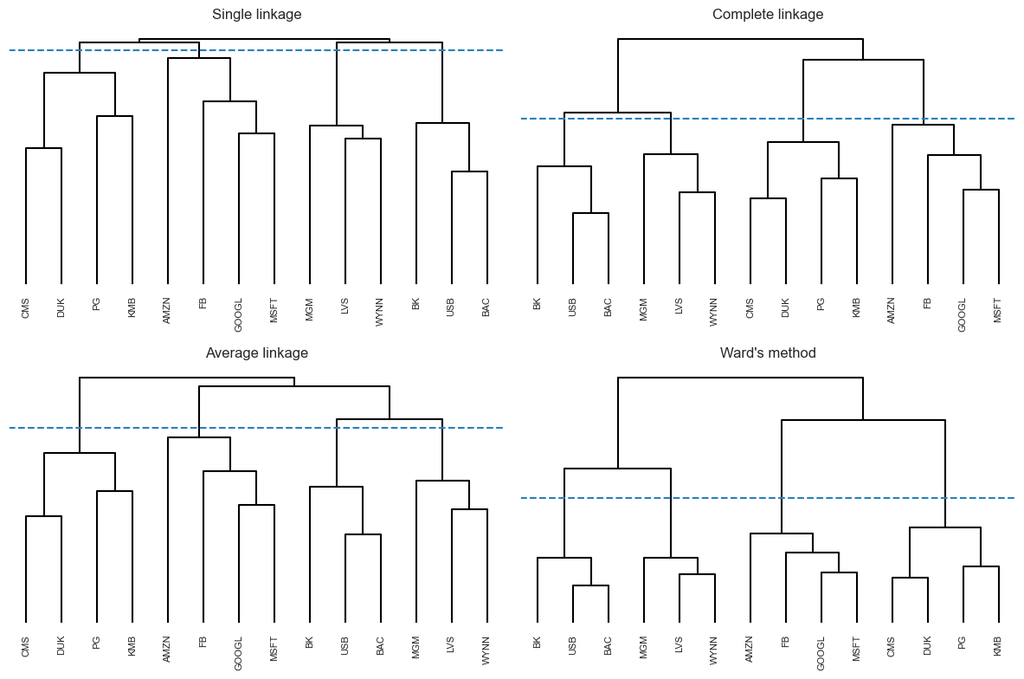

```python
fig, axes = plt.subplots(2, 2, figsize=(12, 8))
for ax, method, title in zip(axes.ravel(),
                             ["single", "complete", "average", "ward"],
                             ["Single linkage", "Complete linkage",
                              "Average linkage", "Ward's method"]):
    Z = hclust(D, method)
    dendrogram(Z, ax=ax, labels=list(stock_prices.columns), leaf_rotation=90,
               leaf_font_size=8, color_threshold=0, above_threshold_color=BLACK)
    # cut into four clusters
    height = (Z[-4, 2] + Z[-3, 2]) / 2
    ax.axhline(height, color=BLUE, linestyle="--")
    ax.set_title(title)
    ax.set_yticks([])
    ax.set_ylabel(None)
    ax.set_facecolor("white")
    ax.grid(False)
plt.tight_layout()
plt.show()
```

The four methods agree on the broad groups (casinos, banks, technology) and differ on how the defensive stocks (utilities and consumer staples) are attached, which is what the last section of this notebook evaluates empirically.

## Quasi-diagonalization of the correlation matrix

Reordering the assets according to the dendrogram (the *quasi-diagonalization* of the correlation matrix) reveals the block structure that the clustering has found:

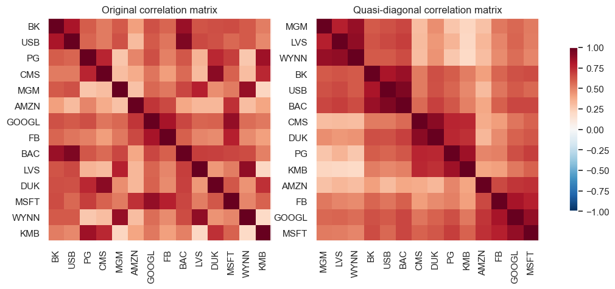

```python
def reorder_cormat(cormat, method="single"):
    """
    Reorder a correlation matrix according to the leaves of the dendrogram.

    Parameters
    ----------
    cormat : np.ndarray
        Correlation matrix.
    method : str, default "single"
        Linkage method.

    Returns
    -------
    cormat_ordered : np.ndarray
        Reordered correlation matrix.
    order : list of int
        Order of the assets (indices of the original matrix).
    """
    D = np.sqrt(np.clip(0.5 * (1 - cormat), 0, None))
    Z = hclust(squareform(pdist(D)), method)
    order = leaves_order(Z, len(cormat))
    return cormat[np.ix_(order, order)], order


cormat = np.corrcoef(X.values, rowvar=False)
cormat_names = list(stock_prices.columns)
cormat_ordered, order = reorder_cormat(cormat)
names_ordered = [cormat_names[i] for i in order]

_, axes = plt.subplots(1, 2, figsize=(13, 5))
for ax, mat, names, title in [(axes[0], cormat, cormat_names, "Original correlation matrix"),
                              (axes[1], cormat_ordered, names_ordered,
                               "Quasi-diagonal correlation matrix")]:
    im = ax.imshow(mat, cmap="RdBu_r", vmin=-1, vmax=1)
    ax.set_xticks(range(len(names)))
    ax.set_xticklabels(names, rotation=90)
    ax.set_yticks(range(len(names)))
    ax.set_yticklabels(names)
    ax.set_title(title)
    ax.set_facecolor("white")
    ax.grid(False)
fig.colorbar(im, ax=axes, shrink=0.7)
plt.show()
```

# Hierarchical clustering-based portfolios

## Hierarchical $1/N$ portfolio

We now compare the different versions of the hierarchical $1/N$ portfolio in a backtest with the fourteen stocks: 70% of the data are used as the initial lookback window, the portfolios are re-optimized every 30 days and rebalanced daily.

### Different linkage methods

The design functions receive a window of prices and compute the log-returns internally, exactly as in the R companion:

```python
def returns_from_window(prices):
    """Log-returns of a window of prices."""
    return np.log(prices).diff().dropna().values


def EWP(prices):
    """Equally weighted (1/N) portfolio."""
    N = prices.shape[1]
    return np.full(N, 1.0 / N)


def GMVP(prices):
    """Global minimum variance portfolio."""
    X_win = returns_from_window(prices)
    return design_GMVP(np.cov(X_win, rowvar=False))


def MVP(prices):
    """Mean-variance portfolio."""
    X_win = returns_from_window(prices)
    return design_MVP(X_win.mean(axis=0), np.cov(X_win, rowvar=False))


def H1overN_single(prices):
    return design_H1overN(X=returns_from_window(prices), linkage="single", distance="corr-dist")


def H1overN_complete(prices):
    return design_H1overN(X=returns_from_window(prices), linkage="complete", distance="corr-dist")


def H1overN_average(prices):
    return design_H1overN(X=returns_from_window(prices), linkage="average", distance="corr-dist")


def H1overN_Ward(prices):
    return design_H1overN(X=returns_from_window(prices), linkage="Ward", distance="corr-dist")
```

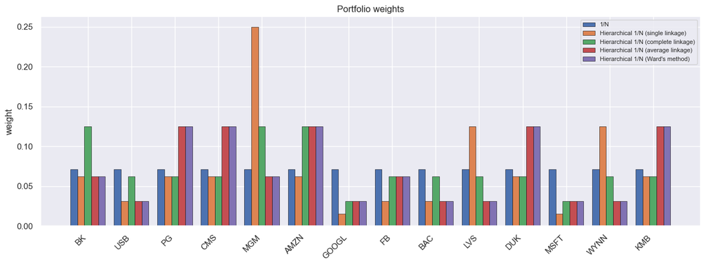

```python
T = len(stock_prices)
T_trn = round(0.70 * T)

bt_linkage = {
    "1/N": EWP,
    "Hierarchical 1/N (single linkage)": H1overN_single,
    "Hierarchical 1/N (complete linkage)": H1overN_complete,
    "Hierarchical 1/N (average linkage)": H1overN_average,
    "Hierarchical 1/N (Ward's method)": H1overN_Ward,
}
returns_linkage, weights_linkage = backtest(bt_linkage, stock_prices, lookback=T_trn,
                                            optimize_every=30, rebalance_every=1)

plot_weights({name: weights_linkage[name].iloc[0].values for name in bt_linkage},
             list(stock_prices.columns))
```

The weights show the structure of the clustering: the hierarchical designs spread the allocation across the clusters and inside each cluster, whereas $1/N$ is flat by construction.

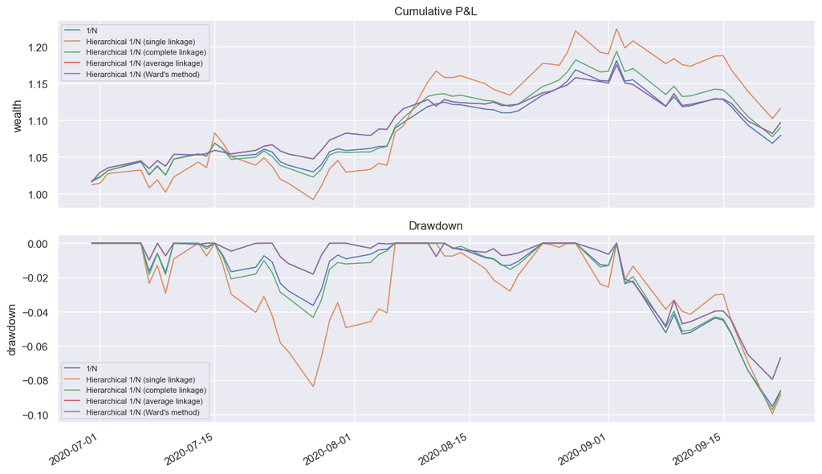

```python
plot_backtest(returns_linkage)
```

### Different distance matrices

Next, we compare the distance matrices: the plain correlation distance and its distance-of-distance, plus two rank-based dependence measures and the distance correlation. (These last three are the Python counterparts of the heavy-tail graph distances of the R companion, since the `fingraph` estimators are not available in Python.)

```python
def H1overN_Ward_dist2(prices):
    return design_H1overN(X=returns_from_window(prices), linkage="Ward", distance="corr-dist2")


def H1overN_Ward_spearman(prices):
    return design_H1overN(X=returns_from_window(prices), linkage="Ward", distance="spearman")


def H1overN_Ward_kendall(prices):
    return design_H1overN(X=returns_from_window(prices), linkage="Ward", distance="kendall")


def H1overN_Ward_distcorr(prices):
    return design_H1overN(X=returns_from_window(prices), linkage="Ward", distance="distance-corr")
```

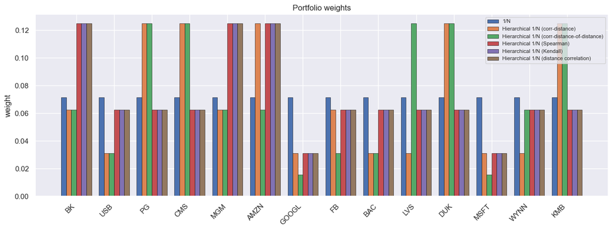

```python
bt_distance = {
    "1/N": EWP,
    "Hierarchical 1/N (corr-distance)": H1overN_Ward,
    "Hierarchical 1/N (corr-distance-of-distance)": H1overN_Ward_dist2,
    "Hierarchical 1/N (Spearman)": H1overN_Ward_spearman,
    "Hierarchical 1/N (Kendall)": H1overN_Ward_kendall,
    "Hierarchical 1/N (distance correlation)": H1overN_Ward_distcorr,
}
returns_distance, weights_distance = backtest(bt_distance, stock_prices, lookback=T_trn,
                                              optimize_every=30, rebalance_every=1)

plot_weights({name: weights_distance[name].iloc[0].values for name in bt_distance},
             list(stock_prices.columns))
```

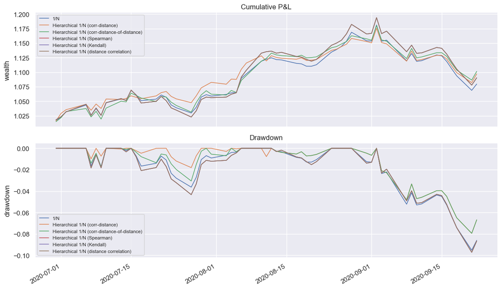

```python
plot_backtest(returns_distance)
```

The choice of the distance matrix changes the weights (the rank-based measures are less influenced by the extreme days of the sample) but, again, the differences in performance are small.

### Final comparison

Finally, we compare the selected version of the hierarchical $1/N$ portfolio (Ward's method with the correlation-based distance-of-distance matrix) with the $1/N$, GMVP and MVP benchmarks:

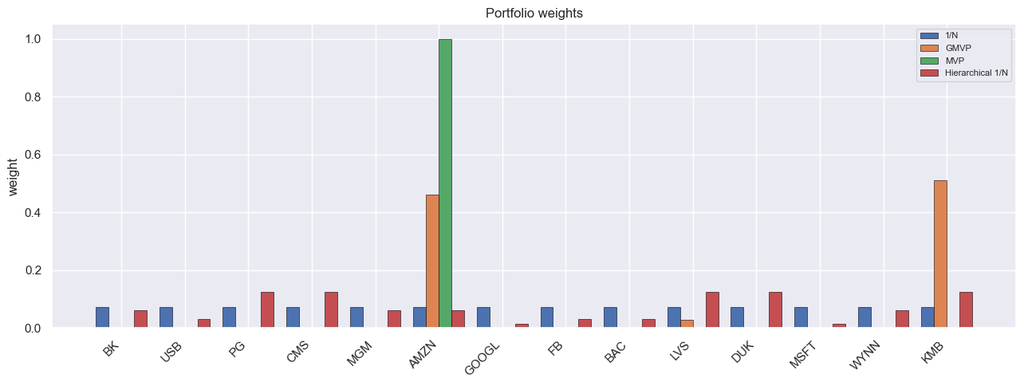

```python
bt_final = {
    "1/N": EWP,
    "GMVP": GMVP,
    "MVP": MVP,
    "Hierarchical 1/N": H1overN_Ward_dist2,
}
returns_final, weights_final = backtest(bt_final, stock_prices, lookback=T_trn,
                                        optimize_every=30, rebalance_every=1)

plot_weights({name: weights_final[name].iloc[0].values for name in bt_final},
             list(stock_prices.columns))
```

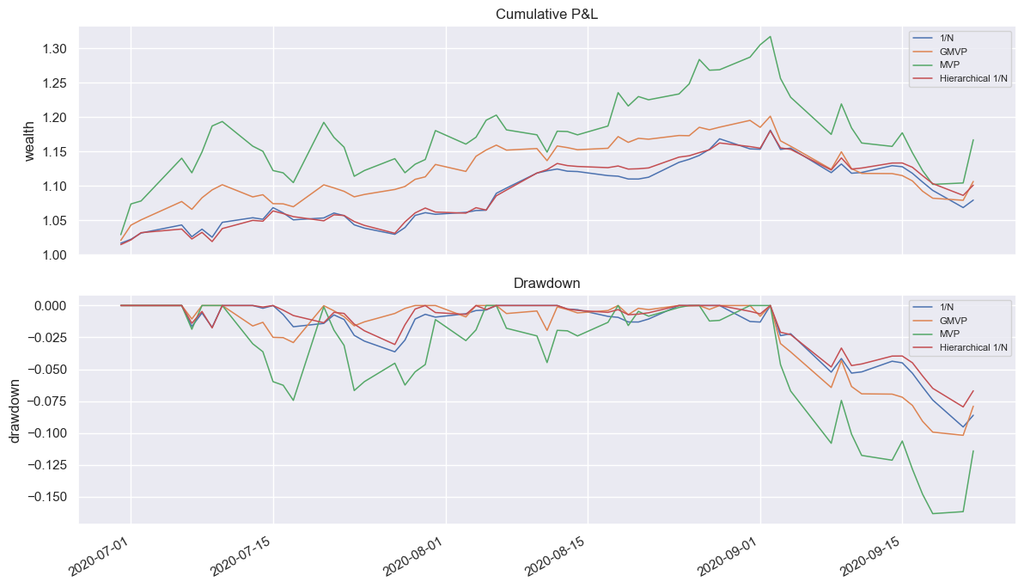

```python
plot_backtest(returns_final)
```

The hierarchical $1/N$ portfolio sits between the naive diversification and the optimized portfolios: it inherits part of the diversification of $1/N$ and part of the risk control of the GMVP, which is the motivation for the whole family of graph-based portfolios.

## Hierarchical risk parity (HRP) portfolio

```python
def IVarP(prices):
    """Inverse-variance portfolio."""
    X_win = returns_from_window(prices)
    return design_IVarP(np.cov(X_win, rowvar=False))


def HRP_bisection(prices):
    return design_HRP(X=returns_from_window(prices), splitting="bisection", linkage="single",
                      distance="corr-dist2")


def HRP_dendrogram(prices):
    return design_HRP(X=returns_from_window(prices), splitting="dendrogram", linkage="single",
                      distance="corr-dist2")


def HRP_dendrogram_spearman(prices):
    return design_HRP(X=returns_from_window(prices), splitting="dendrogram", linkage="single",
                      distance="spearman")


def HRP_dendrogram_distcorr(prices):
    return design_HRP(X=returns_from_window(prices), splitting="dendrogram", linkage="single",
                      distance="distance-corr")
```

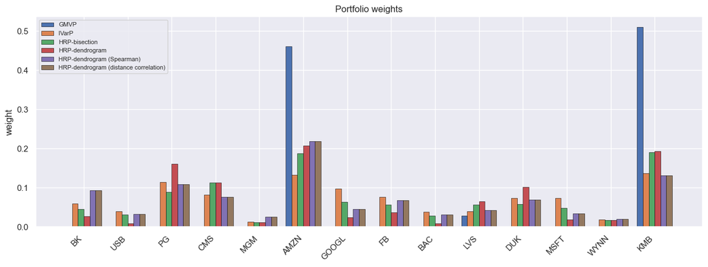

```python
bt_hrp = {
    "GMVP": GMVP,
    "IVarP": IVarP,
    "HRP-bisection": HRP_bisection,
    "HRP-dendrogram": HRP_dendrogram,
    "HRP-dendrogram (Spearman)": HRP_dendrogram_spearman,
    "HRP-dendrogram (distance correlation)": HRP_dendrogram_distcorr,
}
returns_hrp, weights_hrp = backtest(bt_hrp, stock_prices, lookback=T_trn,
                                    optimize_every=30, rebalance_every=1)

plot_weights({name: weights_hrp[name].iloc[0].values for name in bt_hrp},
             list(stock_prices.columns))
```

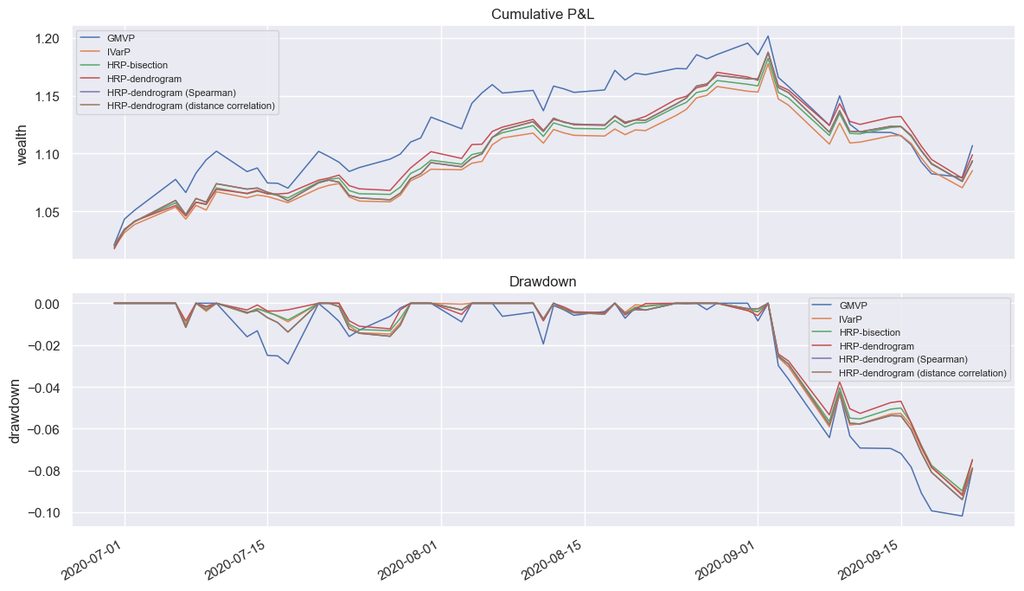

```python
plot_backtest(returns_hrp)
```

The HRP weights are more balanced than the GMVP (which concentrates the allocation on two stocks with small covariances with the rest of the panel) and comparable to the inverse-variance portfolio, with the cluster variances modulating the split between groups of stocks.

## Hierarchical equal risk contribution (HERC) portfolio

For simplicity, the weight splitting of the HERC portfolio uses the two risk contribution measures $\textm{RC}_i = 1$ and $\textm{RC}_i = 1/\sigma_i^2$, leading to a 50%--50% split (as in the hierarchical $1/N$ portfolio) or to $$ \begin{bmatrix} w_1\\ w_2 \end{bmatrix} = \begin{bmatrix} \sigma_1^{-2}/(\sigma_1^{-2} + \sigma_2^{-2})\\ \sigma_2^{-2}/(\sigma_1^{-2} + \sigma_2^{-2}) \end{bmatrix} = \begin{bmatrix} \sigma_2^{2}/(\sigma_1^{2} + \sigma_2^{2})\\ \sigma_1^{2}/(\sigma_1^{2} + \sigma_2^{2}) \end{bmatrix}, $$ as in the HRP portfolio. Both versions are obtained with the functions above, stopping the recursion after a few clusters and then allocating the weight inside each cluster:

```python
def H1overN_Ward_dist2_dendrogram(prices):
    return design_H1overN(X=returns_from_window(prices), splitting="dendrogram", linkage="Ward",
                          distance="corr-dist2")


def HERC_1overN_dendrogram(prices):
    return design_H1overN(X=returns_from_window(prices), splitting="dendrogram", num_clusters=4,
                          linkage="Ward", distance="corr-dist2")


def HERC_1overN_bisection(prices):
    return design_H1overN(X=returns_from_window(prices), splitting="bisection", num_clusters=4,
                          linkage="Ward", distance="corr-dist2")


def HERC_IVarP_dendrogram(prices):
    return design_HRP(X=returns_from_window(prices), splitting="dendrogram", num_clusters=4,
                      linkage="Ward", distance="corr-dist2", final="1/N")


def HERC_IVarP_bisection(prices):
    return design_HRP(X=returns_from_window(prices), splitting="bisection", num_clusters=4,
                      linkage="Ward", distance="corr-dist2", final="1/N")
```

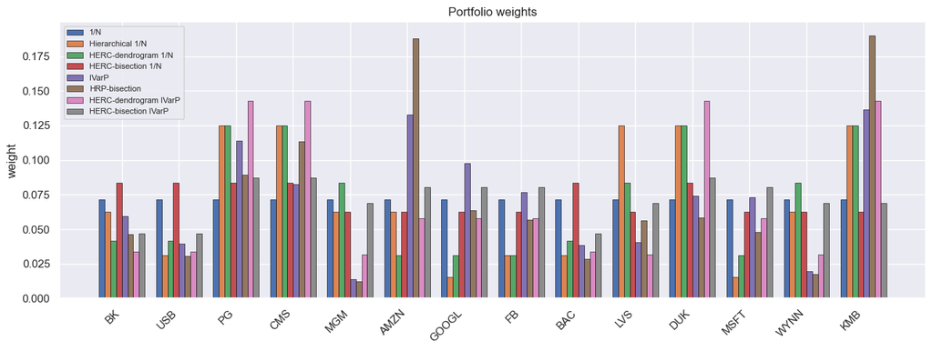

```python
bt_herc = {
    "1/N": EWP,
    "Hierarchical 1/N": H1overN_Ward_dist2_dendrogram,
    "HERC-dendrogram 1/N": HERC_1overN_dendrogram,
    "HERC-bisection 1/N": HERC_1overN_bisection,
    "IVarP": IVarP,
    "HRP-bisection": HRP_bisection,
    "HERC-dendrogram IVarP": HERC_IVarP_dendrogram,
    "HERC-bisection IVarP": HERC_IVarP_bisection,
}
returns_herc, weights_herc = backtest(bt_herc, stock_prices, lookback=T_trn,
                                      optimize_every=30, rebalance_every=1)

plot_weights({name: weights_herc[name].iloc[0].values for name in bt_herc},
             list(stock_prices.columns))
```

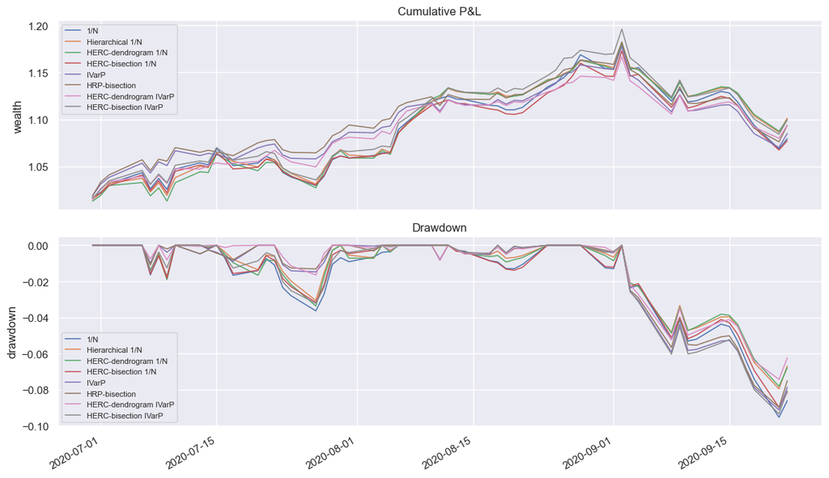

```python
plot_backtest(returns_herc)
```

With four clusters, the HERC portfolios allocate the weight first to the four groups of stocks and then uniformly inside each cluster, so all the stocks of a group receive the same weight: that is why the HERC 1/N weights are flat within each block of the dendrogram, unlike the HRP weights.

# Multiple backtests

After overviewing several graph-based portfolios and observing the performance over single backtests, we now resort to an empirical evaluation based on multiple randomized backtests. In particular, we take a dataset of the S&P 500 stocks over the period 2015--2020 and generate 100 resamples (the R companion uses 200), each with $N=50$ randomly selected stocks and a random period of two years. Then, for each resample, we perform a walk-forward backtest with a lookback window of 1 year, reoptimizing the portfolio every month, rebalancing every five days, and charging a transaction cost of 60 basis points. Nevertheless, more exhaustive backtests should be conducted with a wide variety of data before drawing any firm conclusion.

```python
stock_panel = SP500_stocks_2015to2020

datasets = resample_datasets(stock_panel, num_datasets=100, N_sample=50, T_sample=252 * 2, seed=42)
print(f"{len(datasets)} datasets of {datasets[0].shape[0]} days and {datasets[0].shape[1]} stocks")
```

```
100 datasets of 504 days and 50 stocks
```

## Splitting: bisection versus dendrogram

We start comparing the two splitting methods considered: direct bisection (after reordering the assets with the dendrogram) and following the natural splits of the dendrogram. In principle, one may expect that following the natural dendrogram should be more faithful to the structure in the actual data, as opposed to bisection that somehow breaks the dendrogram. Interestingly, the empirical evaluation seems to suggest otherwise. One possible explanation is that bisection provides more balanced clusters while still using the reordering information provided by the dendrogram.

The ten portfolios of the comparison:

```python
def H1overN_bisection(prices):
    return design_H1overN(X=returns_from_window(prices), splitting="bisection", linkage="Ward",
                          distance="corr-dist2")


def H1overN_dendrogram(prices):
    return design_H1overN(X=returns_from_window(prices), splitting="dendrogram", linkage="Ward",
                          distance="corr-dist2")


def HRP_bisection_single(prices):
    return design_HRP(X=returns_from_window(prices), splitting="bisection", linkage="single",
                      distance="corr-dist2")


def HRP_dendrogram_single(prices):
    return design_HRP(X=returns_from_window(prices), splitting="dendrogram", linkage="single",
                      distance="corr-dist2")


def HERC_1overN_bisection_10(prices):
    return design_H1overN(X=returns_from_window(prices), splitting="bisection", num_clusters=10,
                          linkage="Ward", distance="corr-dist2")


def HERC_1overN_dendrogram_10(prices):
    return design_H1overN(X=returns_from_window(prices), splitting="dendrogram", num_clusters=10,
                          linkage="Ward", distance="corr-dist2")


def HERC_IVarP_bisection_10(prices):
    return design_HRP(X=returns_from_window(prices), splitting="bisection", num_clusters=10,
                      linkage="Ward", distance="corr-dist2", final="1/N")


def HERC_IVarP_dendrogram_10(prices):
    return design_HRP(X=returns_from_window(prices), splitting="dendrogram", num_clusters=10,
                      linkage="Ward", distance="corr-dist2", final="1/N")


bt_splitting = {
    "1/N": EWP,
    "Hierarchical 1/N - bisection": H1overN_bisection,
    "Hierarchical 1/N - dendrogram": H1overN_dendrogram,
    "HERC 1/N - bisection": HERC_1overN_bisection_10,
    "HERC 1/N - dendrogram": HERC_1overN_dendrogram_10,
    "IVarP": IVarP,
    "HRP - bisection": HRP_bisection_single,
    "HRP - dendrogram": HRP_dendrogram_single,
    "HERC IVarP - bisection": HERC_IVarP_bisection_10,
    "HERC IVarP - dendrogram": HERC_IVarP_dendrogram_10,
}
```

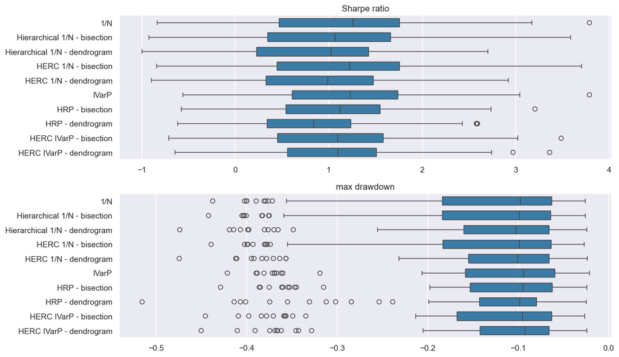

```python
results_splitting = multiple_backtests(bt_splitting, datasets, lookback=252, optimize_every=20,
                                       rebalance_every=5, cost=60e-4, verbose=False)

plot_metric_boxplots(results_splitting, figsize=(12, 7))
```

The boxplots show the distribution of the Sharpe ratio and of the maximum drawdown across the 100 resampled datasets. The differences between bisection and dendrogram splitting are small compared with the dispersion across datasets, which is the honest conclusion of the chapter: both ways of splitting the tree give similar portfolios, and no method dominates.

## Graph estimation: simple versus sophisticated

Now we evaluate whether the more sophisticated dependence measures can bring any benefit to the portfolios. In principle, one may expect a positive answer, but the empirical results show that this is not so clear and further analysis is required. We use a smaller number of datasets (50) because the rank-based measures are more expensive to compute than the sample correlation, and we keep the bisection splitting (which is the fastest and, as seen above, not worse than the dendrogram).

```python
def H1overN_spearman(prices):
    return design_H1overN(X=returns_from_window(prices), splitting="bisection", linkage="Ward",
                          distance="spearman")


def H1overN_kendall(prices):
    return design_H1overN(X=returns_from_window(prices), splitting="bisection", linkage="Ward",
                          distance="kendall")


def HRP_spearman(prices):
    return design_HRP(X=returns_from_window(prices), splitting="bisection", linkage="single",
                      distance="spearman")


def HRP_kendall(prices):
    return design_HRP(X=returns_from_window(prices), splitting="bisection", linkage="single",
                      distance="kendall")


bt_graph = {
    "1/N": EWP,
    "Hierarchical 1/N (Pearson)": H1overN_bisection,
    "Hierarchical 1/N (Spearman)": H1overN_spearman,
    "Hierarchical 1/N (Kendall)": H1overN_kendall,
    "IVarP": IVarP,
    "HRP (Pearson)": HRP_bisection_single,
    "HRP (Spearman)": HRP_spearman,
    "HRP (Kendall)": HRP_kendall,
}
```

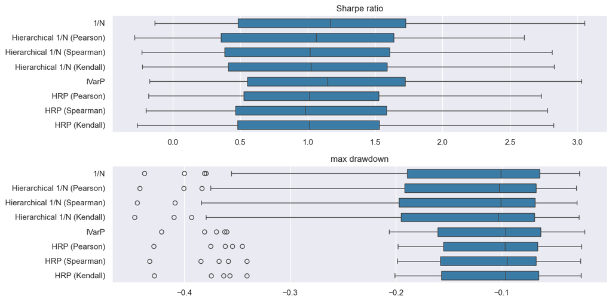

```python
datasets_graph = resample_datasets(stock_panel, num_datasets=50, N_sample=50, T_sample=252 * 2,
                                   seed=42)

results_graph = multiple_backtests(bt_graph, datasets_graph, lookback=252, optimize_every=20,
                                   rebalance_every=5, cost=60e-4, verbose=False)

plot_metric_boxplots(results_graph, figsize=(12, 6))
```

Again, the differences between the simple sample correlation and the rank-based dependence measures are small compared with the variability across datasets: a more sophisticated estimate of the graph does not translate into a clearly better portfolio, which is consistent with the conclusion of the chapter for the heavy-tail graph estimators.

## Final comparison

Finally, we perform a comparison of the graph-based portfolios (using the simple graph-based distance-of-distance matrix), along with the benchmarks $1/N$ portfolio and IVarP, namely the hierarchical $1/N$ portfolio, the HERC $1/N$ portfolio, the HRP portfolio, and the HERC IVarP portfolio:

```python
bt_comparison = {
    "1/N": EWP,
    "Hierarchical 1/N": H1overN_bisection,
    "HERC 1/N": HERC_1overN_bisection_10,
    "IVarP": IVarP,
    "HRP": HRP_bisection_single,
    "HERC IVarP": HERC_IVarP_bisection_10,
}
```

```python
results_comparison = multiple_backtests(bt_comparison, datasets, lookback=252, optimize_every=20,
                                        rebalance_every=5, cost=60e-4, verbose=False)

measures = ["Sharpe ratio", "annual return", "annual volatility", "Sortino ratio", "max drawdown"]
summary = results_comparison.groupby("portfolio")[measures].median().loc[list(bt_comparison)]
summary.round(3)
```

| portfolio | Sharpe ratio | annual return | annual volatility | Sortino ratio | max drawdown |
| --- | --- | --- | --- | --- | --- |
| 1/N | 1.259 | 0.150 | 0.126 | 1.718 | -0.098 |
| Hierarchical 1/N | 1.068 | 0.132 | 0.126 | 1.514 | -0.099 |
| HERC 1/N | 1.222 | 0.147 | 0.126 | 1.676 | -0.099 |
| IVarP | 1.227 | 0.138 | 0.116 | 1.691 | -0.095 |
| HRP | 1.117 | 0.120 | 0.112 | 1.553 | -0.095 |
| HERC IVarP | 1.097 | 0.128 | 0.118 | 1.551 | -0.096 |

The table reports the medians across the 100 resampled datasets. The empirical results show that the different methods do not appear significantly different, and a more exhaustive comparison is needed before drawing any clear conclusion.

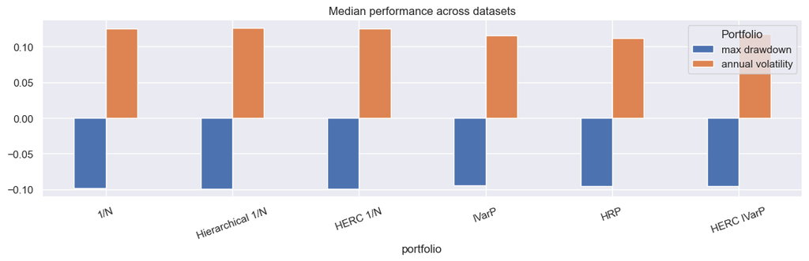

```python
summary[["max drawdown", "annual volatility"]].plot(kind="bar", figsize=(12, 4), rot=20)
plt.ylabel(None)
plt.legend(title="Portfolio")
plt.title("Median performance across datasets")
plt.tight_layout()
plt.show()
```

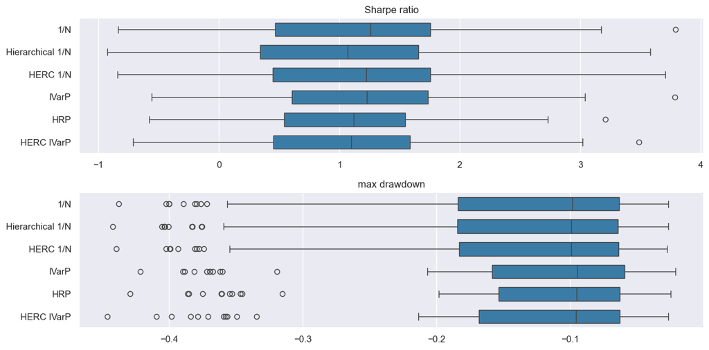

```python
plot_metric_boxplots(results_comparison, figsize=(12, 6))
```

# Summary